# Lab 11

Steven Cabrera

2022-11-09

```
## Plot coordinates for graph not supplied! Generating coordinates, see ?coordinates for how to set your own.
```

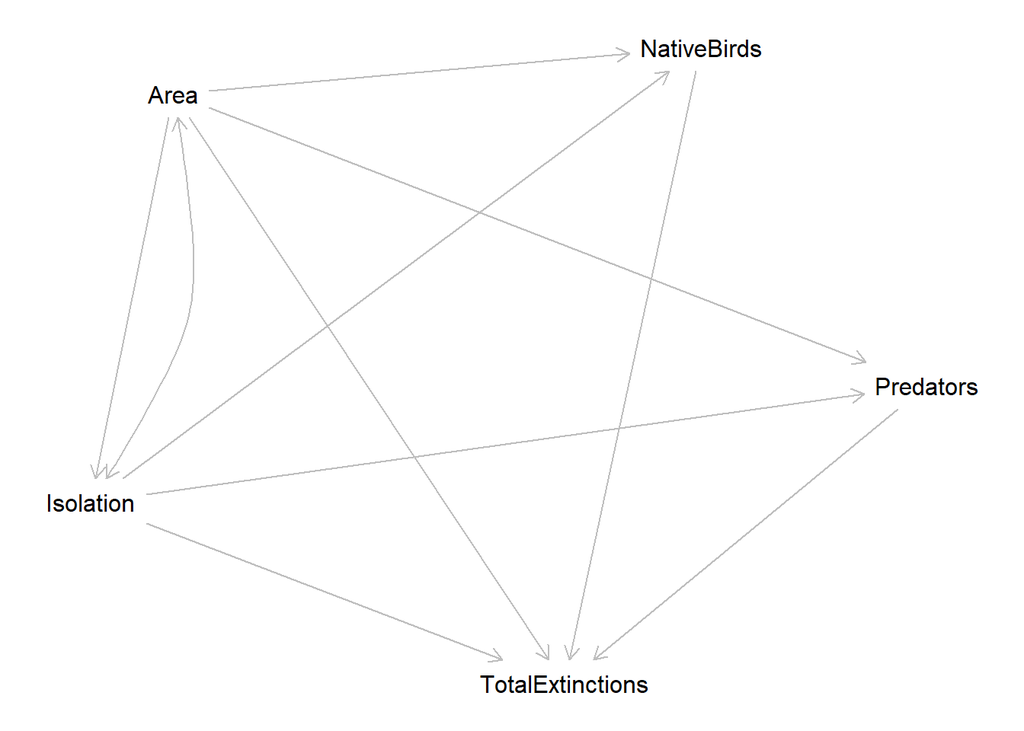

```r
plot(testy)
```

2. Inlcude “Isolation” only with “Area”
3. For each 100,000-ha increase in area, we observed 1.66 (1.56 - 1.75; 95% C.L) times as many extinctions (p < 2e-16).
4. The vif of area and isolation is 1.095.
5. For each 100,000-ha increase in area, we observed 0.85 (0.74 - 0.98; 95% C.L) times as many extinctions (p = 0.026). **This model has overcontrol bias.**
6. Using step-wise regression, we included all of the variables in the global model because they were all significant.
7. The predicted number of extinctions for an island of 20,000 ha, 2000 km from the mainland, with 30 native birds, and 0 predators is **1.07**.
8. The link between isolation and total extinctions is necessary because the relationship is significant - for each 1-km increase in isolation, we observed a 1.63 (1.54 - 1.72; 95% CL) times as many extinctions (p < 2e-16).
9. Yes, latitude could be potentially important. It is significant when added to the model (p = 0.000454), but acts as a child due to it probably does not influence the other variables.